# C-CUBES Stratonomics

A forum to unpack and share the data science embedded in the C-CUBES philosophy .

Hari Sridhar, Ashwin Malshe and Vikas Mittal https://ccubes.net (C-CUBES)  
2021-05-17

## DOn’t Confuse Salience with Importance

In our book **[FOCUS](https://focus-book.net/)**, we narrate the story of FOODCO, a lunch-focused restaurant chain with 22 locations in a major metropolitan city.

During a strategy planning meeting, the owner of the chain says, *“We sell over a million meals a year because of our extensive menu of offerings and high quality. Last week, two customers from a restaurant thanked me for the expanded menu selection and high-quality food. We need to emphasize these benefits to improve customer value and sales.”*

The restaurant-chain owner bases his proposed strategy on **salience**—he easily recalls two benefits that customers have mentioned in conversations with him.The salience of a strategic area is measured by the probability with which a benefit is recalled and mentioned by a customer. In everyday life, salience is the extent to which some facts and perceptual elements are prominent and top-of-mind as well as easier to recall, remember, and imagine than others.

Many salient benefits may not actually be important to customers, and vice versa. Due to its ease and higher probability of recall, salient information is often incorrectly perceived as being important. Many times, people incorrectly emphasize salient information in their decision-making. The way a job candidate dresses may be salient to an interviewer but it may be completely unimportant for job performance.

To arrive at a focused and customer-based strategy, executives need to base their strategy on **importance**. The importance of a strategic area is the strength of the association between the strategic area and a desired outcome, such as overall satisfaction, word-of-mouth, or purchase behavior. Many benefits are important to customers, even though they may not be salient.Customers who have read about a local plane crash may consider safety to be a salient issue. But when traveling on a long-haul flight, they may actually find benefits like comfort (seating, legroom, blankets, and pillows) and pricing (tickets, free luggage, and carry-ons allowed) to be the most important drivers of their overall satisfaction with the trip.

Let’s walk through the technicalities behind salience and importance, to avoid falling for the salience trap while formulating strategy.

## Salience Formation From Unstructured Conversations

Word cloud is shown below

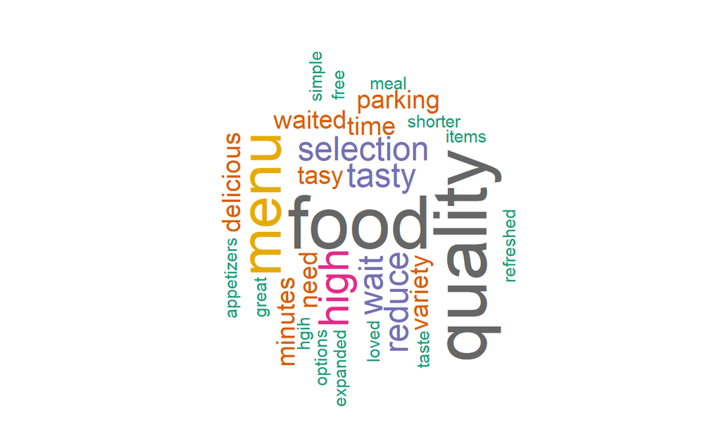

[interactive chart not shown]

most frequent Words are shown below

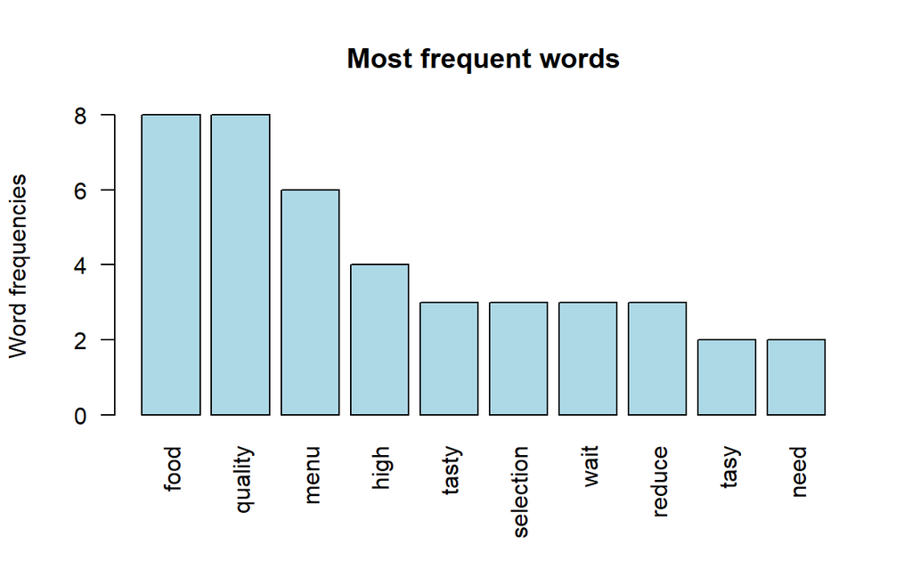

Distribution of most salient areas are shown below

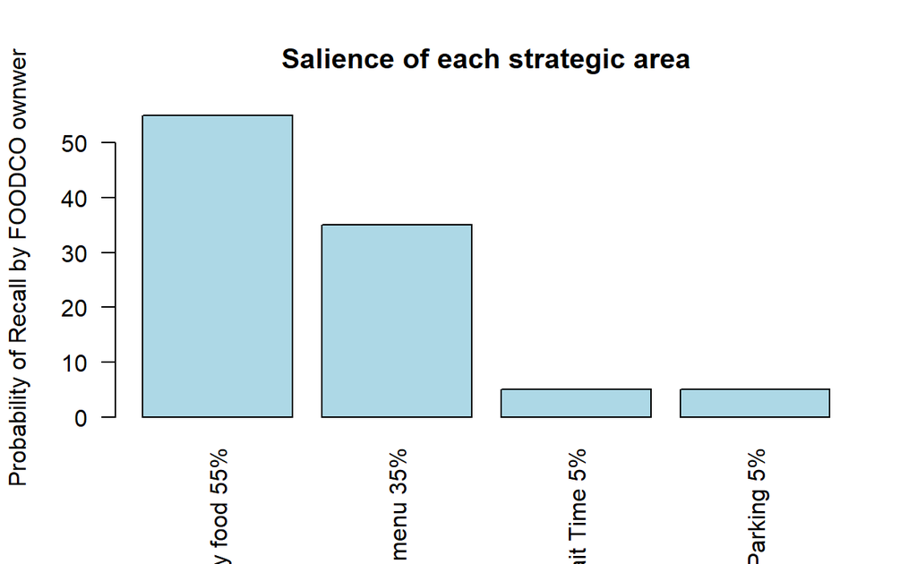

## Steps in Calculating Importance

To calculate the importance of a strategy factor without mental biases, senior executives at a firm must implement the following steps:

## Strategy Dilemma at FOODCO

When the lunch-focused restaurant chain FOODCO was hit with stagnating sales, its CEO and owner wanted to improve his strategy. He focused on the many different menu items he believed would preserve FOODCO’s “high quality”—freshly prepared sandwiches, soups, and salads. Yet, customer surveys showed that customers wanted a fast dining experience with a short wait time, a simple menu with few items, ample parking, and a bill lower than $12 per meal, drinks included. The survey results contrasted starkly with the strategy direction FOODCO’s owner charted. When FOODCO’s owner read the survey findings, he said, “This validates what has been clear to me all along. We have to lead and not be led. Too often, customers don’t know what they want, and we have to shape their needs. Look at Apple. We need a winning strategy that differentiates our brands, and we can do that by offering the largest selection of freshly prepared foods at the lowest price point in the marketplace.”

## Conclusion

A firm’s value proposition and customer value equation should be based on benefits important to its customers and strategic areas in which the customers perceive the firm’s performance as being better than its competitors. Many firms focus only on salient customer benefits, ignoring truly important benefits. This is a mistake.

To counteract the damaging effects of salience and prioritize strategy areas based on importance, executives must first conduct a rigorous analysis. They must clearly define their desired outcome and a set of critical inputs. The inputs’ importance must be calculated based on how strongly each is linked to the desired outcome. The process involves linking performance in different strategy areas to the outcome while statistically controlling for confounding extraneous factors.

This brief describes the correct approach to measuring the importance of customer benefits and evaluating a firm’s performance as perceived by customers.